# ------------------------------------------------------------------------------------------

# TASK 1

## **Dual-Line Plot with Markers and Labels:** Plot the revenue and profit for a company over six months on the same graph. Use different markers for each line and ensure the plot has labeled axes, a title, and a legend. Ensure the markers are distinguishable and the lines have different styles.

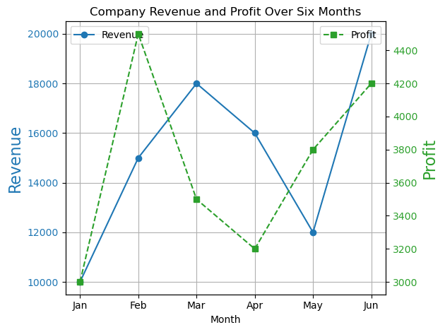

```python
# Importing libraries
import matplotlib.pyplot as plt

# Sample data for six months, along with their revenue and profit
months = ['Jan', 'Feb', 'Mar', 'Apr', 'May', 'Jun']
revenue = [10000, 15000, 18000, 16000, 12000, 20000]
profit = [3000, 4500, 3500, 3200, 3800, 4200]

# Create a figure and axis, to plot multiple plots on a single figure
fig, ax1 = plt.subplots()

# Plot first line plot as 'revenue' with different marker and linestyle
ax1.plot(months, revenue, color='tab:blue', marker='o', linestyle='-', label='Revenue')
ax1.set_xlabel('Month')
ax1.set_ylabel('Revenue', color='tab:blue',fontdict={'fontsize':16})
ax1.tick_params(axis='y', labelcolor='tab:blue')

# Create a second y-axis to plot profit
ax2 = ax1.twinx()     # create invisible X- axis and independent Y-axis
ax2.plot(months, profit, color='tab:green', marker='s', linestyle='--', label='Profit')
ax2.set_ylabel('Profit', color='tab:green',fontdict={'fontsize':16})
ax2.tick_params(axis='y', labelcolor='tab:green')

# Adding title and show grid
plt.title('Company Revenue and Profit Over Six Months')
ax1.grid(True)

# Adding legends
ax1.legend(loc='upper left')
ax2.legend(loc='upper right')

# Show plot and automatically adjusts subplot parameters so that the subplot(s) fits in to the figure area.
plt.tight_layout()
plt.show()
```

## ------------------------------------------------------------------------------------------------------------

# TASK 2

## **Vertical Bar Chart with Annotations:** Create a vertical bar chart showing the number of books read by students in five different grades. Annotate the top of each bar with the exact number of books read. Ensure the bars are colored differently and labeled.

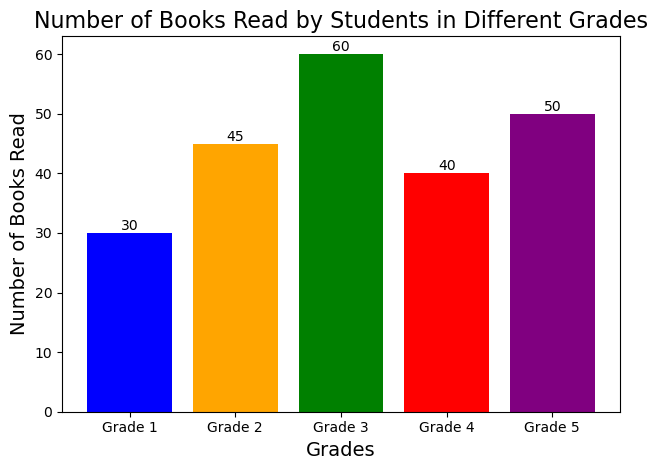

```python
import matplotlib.pyplot as plt

# Data for the vertical bar chart, with different colours
grades = ['Grade 1', 'Grade 2', 'Grade 3', 'Grade 4', 'Grade 5']
books_read = [30, 45, 60, 40, 50]
colors = ['blue', 'orange', 'green', 'red', 'purple']

# Creating the bar chart
fig, ax = plt.subplots()
bars = ax.bar(grades, books_read, color=colors)

# Annotate each bar with the number of books read
for bar in bars:
    height = bar.get_height()  # Get the height of the bar
    # Label the bar with the height value
    ax.text(
        bar.get_x() + bar.get_width() / 2,  # X position (center of the bar)
        height,                             # Y position (top of the bar)
        str(height),                        # Text (number of books read)
        ha='center',                        # Center-align horizontally
        va='bottom'                         # Place text just above the bar
    )

# Labeling the Y-axis, X-axis, and title
ax.set_xlabel('Grades',fontdict={'fontsize':14})
ax.set_ylabel('Number of Books Read',fontdict={'fontsize':14})
ax.set_title('Number of Books Read by Students in Different Grades',fontdict={'fontsize':16})

# Show the plot and automatically adjusts subplot parameters so that the subplot(s) fits in to the figure area.
plt.tight_layout()
plt.show()
```

## ------------------------------------------------------------------------------------------------------------

# TASK 3

## **Customized Pie Chart:** Create a pie chart showing the market share of five smartphone brands. Ensure the slices have different colors, labels with percentages, and explode the slice with the highest market share. Also, rotate the chart to start from a different angle.

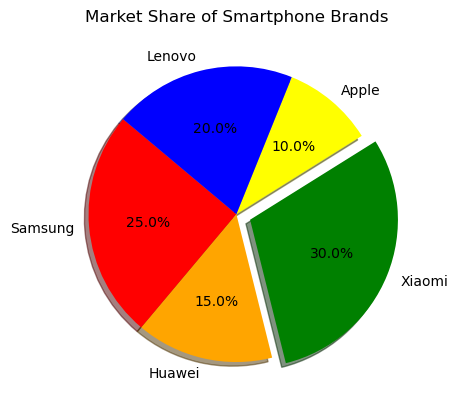

```python
import matplotlib.pyplot as plt

# Data for different smartphone brands for the pie chart, with different colours for each slice.
brands = ['Samsung', 'Huawei', 'Xiaomi', 'Apple', 'Lenovo']
market_share = [25, 15, 30, 10, 20]
colors = ['red','orange','green','yellow','blue']

# Explode the slice with the highest market share
explode = [0.1 if share == max(market_share) else 0 for share in market_share]
# alternative way to use 'explode' to slice with the highest market share
# explode=(0, 0, 0.4, 0, 0)

# Create the pie chart
fig, ax = plt.subplots()
wedges, texts, autotexts = ax.pie(market_share, explode=explode , labels=brands, colors=colors,
    autopct='%1.1f%%',  # Format for the percentage labels
    startangle=140,     # Rotate the pie chart
    shadow=True )       # Add shadow for better visual effect

# Customize the font size of the labels and percentages
for text in texts:
    text.set_fontsize(10)
for autotext in autotexts:
    autotext.set_fontsize(10)

# Set the title
ax.set_title('Market Share of Smartphone Brands')

# Show the plot
plt.show()
```

## ------------------------------------------------------------------------------------------------------------

# TASK 4

## **Subplots with Shared Y-axis:** Create two subplots in a single figure where both plots share the same y-axis. The first plot should show the number of hours studied over a week, and the second should display the number of hours of sleep. Customize the plots with different line styles, markers, and colors. Add a shared y-axis label and individual x-axis labels.

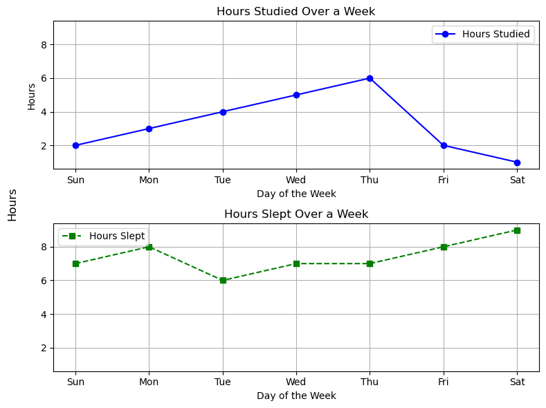

```python
import matplotlib.pyplot as plt

# Data for the subplots
days = ['Sun','Mon', 'Tue', 'Wed', 'Thu', 'Fri', 'Sat']
hours_studied = [2, 3, 4, 5, 6, 2, 1]
hours_slept = [7, 8, 6, 7, 7, 8, 9]

# Create a figure and a set of subplots
fig, (ax1, ax2) = plt.subplots( 2,1,sharey=True, figsize=(8, 6))         # figure has 2 rows and 1 column

# Plot Axis-1: number of hours studied
ax1.plot(days, hours_studied, color='blue', marker='o', linestyle='-', label='Hours Studied')
ax1.set_xlabel('Day of the Week')
ax1.set_ylabel('Hours')
ax1.set_title('Hours Studied Over a Week')
ax1.grid(True)
ax1.legend()

# Plot Axis-2: number of hours slept
ax2.plot(days, hours_slept, color='green', marker='s', linestyle='--', label='Hours Slept')
ax2.set_xlabel('Day of the Week')
ax2.set_title('Hours Slept Over a Week')
ax2.grid(True)
ax2.legend()

# Add a shared y-axis label
fig.supylabel('Hours')

# Adjust layout to prevent overlap
plt.tight_layout()
# Show the plots
plt.show()
```